# Designing Data Science Workshops for Data-Intensive Scientific Research

## Outline

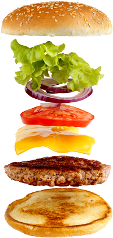

- Research Motivation
- Climate of Computing – Environmental Sciences & Statistics
- Research on Data Science Workshops
  - Design
  - Implementation
  - Evaluation
- Considerations & Future Directions

## A Motivating Vignette

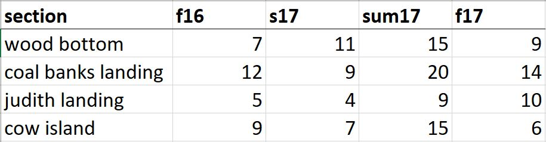

## Data Problems

But the `R` functions you saw in your courses require for your data to be in long format.

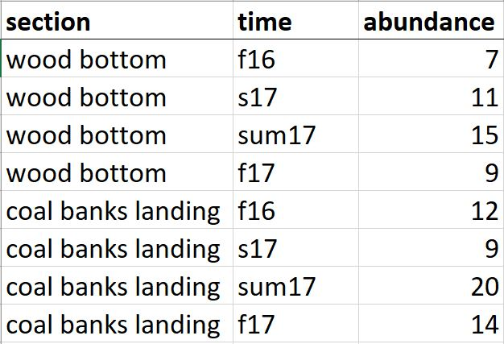

## Data-Intensive Research

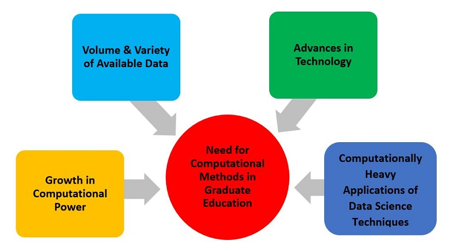

## (Lack of) Computing in Environmental Sciences

- Strasser and Hampton (2012) explored the importance of data management in undergraduate ecology courses.
  - Less than 20% of instructors included data management topics in their courses, despite rating data management as a very important topic for their research.
- A 2012 survey of graduate students:
  - over 80% of students reported that they had received no formal training in computing, even at the most basic level
  - 74% stated that they had no skills in any programming language (Hernandez, Meyernik, Murphy-Mariscal & Allen, 2012).

## Current Climate of Computing – Environmental Sciences

- In 2017, environmental scientists produced a formative paper on the skills necessary for data-intensive environmental science research (Hampton et al.).
  - data management and processing
  - data analysis
  - software skills for science
  - data visualization
  - communication methods for collaboration and dissemination

## Statistics and the Environmental Sciences

- Environmental science educators reiterate the importance of data science skills for students’ participation in “data-intensive” research.
- None of these conversations pay attention to the role a students’ statistics education plays in their attainment of the computing skills necessary for data-intensive research.
- Over the last twenty years, Statistics preparation in the environmental sciences has become vital.
  - Hence, Statistics courses have been incorporated into undergraduate and graduate programs, across the nation.

## (Lack of) Computing in Statistics

- “Most of our students are not prepared for data analysis after their statistics [courses],” because “they have done very little actual data analysis” (Nolan & Temple Lang, 2010).
- Students are either “told to learn how to program by themselves, from each other, or from their teaching assistant in a two-week ‘crash course’ at the start of a course.”
- “What we teach [in Statistics] lags decades behind what we practice” and “the gap between our half-century-old curriculum and our contemporary statistical practice continues to widen” (Cobb, 2015).

## Current Climate of Computing – Statistics

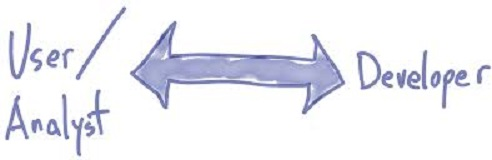

- 2005: `ggplot2` beginning of user friendly `R` tools (Wickham)
- 2012: `RMarkdown` for embedding code in reports
- 2014: ASA updated guidelines for undergraduate programs in Statistics
- 2017: `tidyverse` houses all of the packages necessary for a clean data science workflow

## Barriers to Incorporating Computing

- But why are these skills still so rarely included in the curriculum when the need for them is widely recognized?
  - Courses are potentially taught by people who may not feel prepared teach these topics.
  - Attempting to fit more material into already-full courses and curricula.
  - Not clear what computing topics should be included and how.
  - Not all institutions have the flexibility to develop courses.
- This lack of training in computational skills impedes the progress of scientific research, sends the signal to students that computing is not of intellectual importance, and is laden with hidden costs.

## Research Questions

1. What do environmental science faculty members identify as the key computing skills graduate students require to implement statistics for research in their field?
2. How can the key computing skills identified by environmental science faculty be incorporated into currently existing workshop materials?
3. What are the experiences of individuals attending theses tailored data science workshops?
4. Does the content of these workshops reflect the computing skills used by environmental science graduate students in their research?

## Research Phases

| Research Question | Design Phase | Data Collected |
| --- | --- | --- |
| What do environmental science faculty members identify as the key computing skills graduate student require to implement statistics in environmental science research? | Phase 1 | Faculty interviews |
| How can these key computing skills be incorporated into currently existing workshop materials? | Phase 2 | Carpentries curriculum materials |

## Phases Continued

| Research Question | Design Phase | Data Collected |
| --- | --- | --- |
| What are the experiences of individuals attending data science workshops? | Phase 3 | Pre- and post-workshop surveys |
| Does the content of these workshops reflect the data science skills used by graduate students in their research? |  | Collection of graduate students’ research (`R`) code |

## Computational Expectations

- Working with Data
  - “Organize their data and get it in a way that can be used by `R`”
- Data Visualization
  - Ability to create visualizations of their data early and often
- Reproducibility
  - “Manipulating data in ways that are repeatable”
- Data Context
  - Importance of students acquiring computing skills in familiar data contexts

## Expectations Acquiring Skills

Faculty voiced the expectation that students learn these skills on their own.

- “I think that more and more in our field my generation is sort of just catching up the next generation.”
- “Increasingly faculty feel that way like they’re they’re not at the forefront of the programming abilities and so their students are kind of being self-taught and then are often ahead of them.”
- “I feel personally out of touch, because [students] work in `R` and I haven’t taken the time to learn `R`, because of my training and my age.”

## Resources for Learning `R`

- The Carpentries: teaches foundational coding, and data science skills to researchers worldwide. In person, hands-on, two-day workshops, with publicly available lessons for specific populations of researchers.
  - Software Carpentry
  - Data Carpentry
- `swirl`: an `R` package which turns the `R` console into an interactive learning environment
- Data Camp: interactive `R`, Python, Sheets, SQL and shell courses. Paid online video lessons with coding challenges and projects.

## Benefits of Data Science Workshops

- Approachable training resources for researchers hoping to develop computational skills are scarce (Teal et al., 2015).
  - Current resources assume learners have a basic level of understanding of working in `R`.
- The Carpentries develop publicly available lessons for specific populations of researchers.
  - Does not assume that attendees have any prior knowledge before attending the workshops
- Workshops have the potential to scale more effectively than courses.

## Workshop Development

In 2017, I developed a suite of four 3-hour data science workshops.

- Content: skills distilled from interviews infused into Data & Software Carpentry `R` lessons.
- Structure: interactive exercises build confidence
- Context: environmental science data promote learning transfer

## `R` for Data Science Workshops

| Introduction to `R` | objects in `R`, working in `R`, inspecting, extracting, cleaning, summarizing, and visualizing data with base `R` tools |
| --- | --- |
| Intermediate `R` | relational and logical operators, conditional statements, looping, and user-defined functions |
| Data Wrangling in `R` | data wrangling with `dplyr`, `stringr`, `forcats`, and `lubridate`, data organization with `tidyr` |
| Data Visualization in `R` | grammar of graphics with `ggplot2` |

## Workshop Tools

- RStudio
  - Access to the resources of `R`, in a comfortable working environment
  - Consistent across operating systems!
- RMarkdown Documents
  - Promotes organized code and clean workspaces
  - Exploratory work is situated within each topic
- RStudio Cloud
  - Publicly available workshop materials, without software or package installation, or data transfers
  - Each workshop is contained in an organized `R` project directory

## Data Context

```r
fish <- read_csv("data/BlackfootFish.csv")

glimpse(fish)
```

```
## Observations: 18,352
## Variables: 7
## $ trip    <dbl> 1, 1, 1, 1, 1, 1, 1, 1, 1, 1, 1, 1, 1, 1, 1, 1, 1, 1, 1, 1,...
## $ mark    <dbl> 0, 0, 0, 0, 0, 0, 0, 0, 0, 0, 0, 0, 0, 0, 0, 0, 0, 0, 0, 0,...
## $ length  <dbl> 288, 288, 285, 322, 312, 363, 269, 160, 213, 157, 143, 179,...
## $ weight  <dbl> 175, 190, 245, 275, 300, 380, 170, 40, 80, 35, 35, 70, 100,...
## $ year    <dbl> 1989, 1989, 1989, 1989, 1989, 1989, 1989, 1989, 1989, 1989,...
## $ section <chr> "Johnsrud", "Johnsrud", "Johnsrud", "Johnsrud", "Johnsrud",...
## $ species <chr> "RBT", "RBT", "RBT", "RBT", "RBT", "RBT", "RBT", "RBT", "RB...
```

## Introduction to `R` – Working with Data

```r
mean(fish$weight)
```

```
## [1] NA
```

```r
mean(fish$weight, na.rm = TRUE)
```

```
## [1] 246.2204
```

## Introduction to `R` – Data Visualization

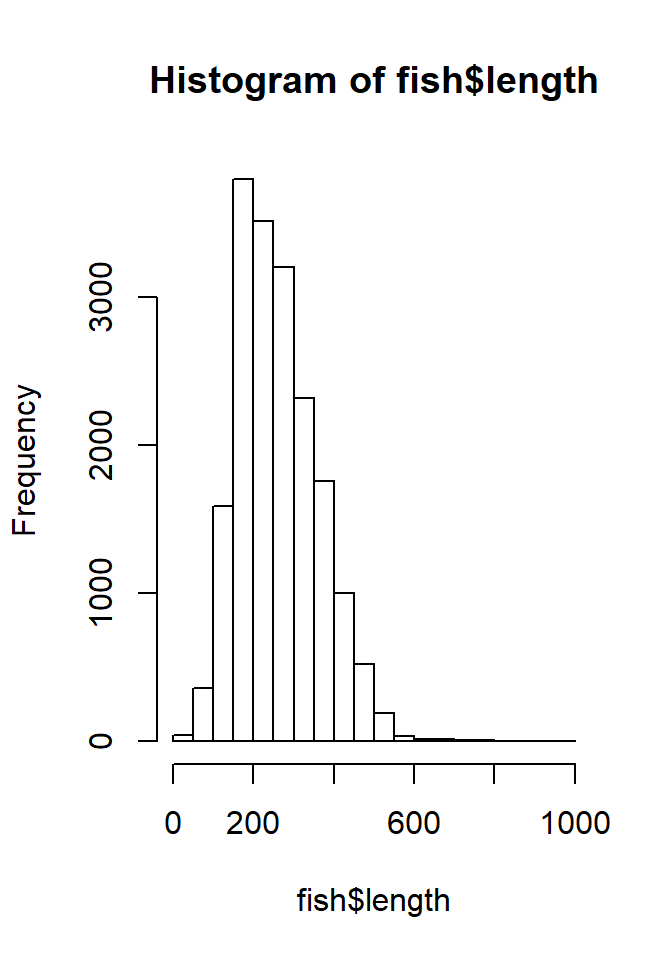

```r
hist(fish$length, bins = 45)
```

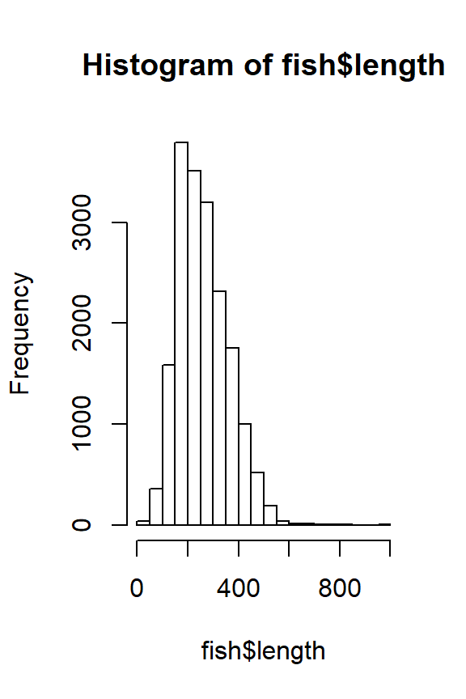

```r
hist(fish$length, bins = 45)
```

```r
plot(weight ~ length, data = fish)
```

[output not shown]

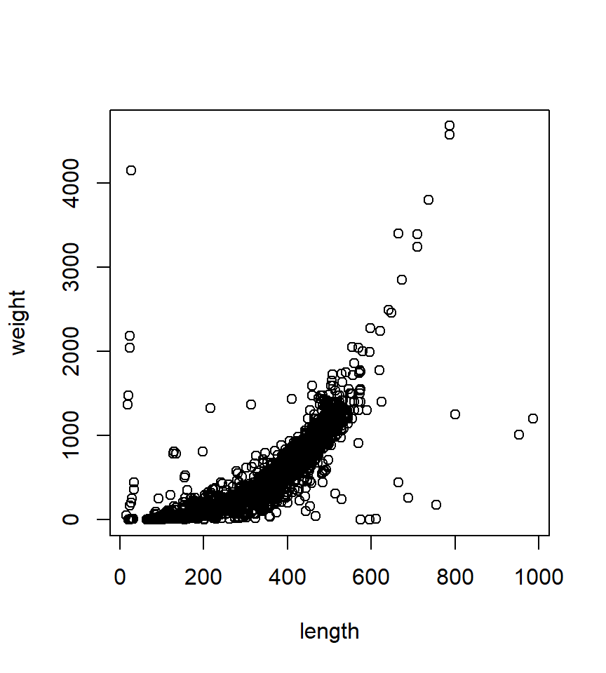

```r
plot(weight ~ length, data = fish)
```

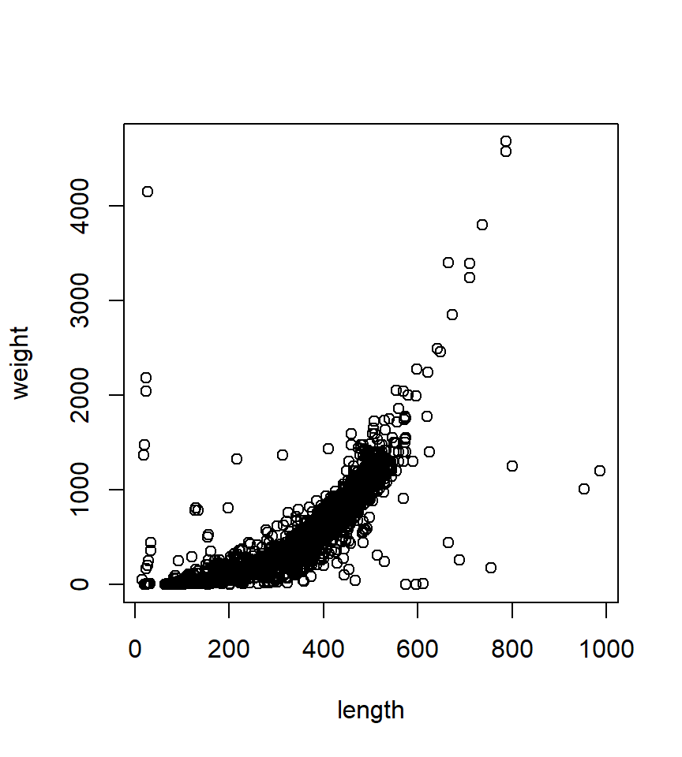

```r
plot(weight ~ length, data = fish)
```